# An Introduction to Inductive Statistical Inference — Worked examples in statistical modelling using R and Stan

Henk van Elst

August 30, 2022

# 1 Introduction

This R Markdown `html_notebook` provides worked examples in statistical modelling accompanying the online lecture notes “An Introduction to Inductive Statistical Inference” (URL: https://arxiv.org/abs/1808.10173). These worked examples are grouped into sections on each of “Fixed effects generalised linear models”, “Varying effects generalised linear models” and “Time series analysis”. The worked examples are coded in the statistical programming languages R and Stan; cf. R Core Team (2022) and Carpenter *et al* (2017). Valuable suggestions on how to make effective use of visualisation in Bayesian workflow have been put forward by Gabry *et al* (2019).

# 2 Load packages

For the worked examples in statistical modelling to be discussed in subsequent sections the following R packages will be loaded: `rstan` by the Stan Development Team (2022b), `bayesplot` by Gabry and Mahr (2022), `loo` by Vehtari *et al* (2022), `tidyverse` by Wickham *et al* (2019), `magrittr` by Bache and Wickham (2022), `GGally` by Schloerke *et al* (2021), `lubridate` by Grolemund and Wickham (2011) and `scales` by Wickham and Seidel (2022).

```r
library(bayesplot)
library(GGally)
library(loo)
library(lubridate)
library(magrittr)
library(rstan)
library(scales)
library(tidyverse)
options(mc.cores = parallel::detectCores())
rstan::rstan_options("required" = FALSE)
rstan::rstan_options(auto_write = TRUE)
rstan::stan_version()
```

```
[1] "2.26.1"
```

# 3 Fixed effects generalised linear models

## 3.1 Linear regression

### 3.1.1 Data and visualisation

**data set** `ashenfelter.RData` by Ashenfelter, Ashmore and Lalonde, URL (cited on August 17, 2022): http://www.liquidasset.com/); cf. Kahneman (2011). Check for an remove NAs.

```r
load("ashenfelter.RData")
attach(what = ashenfelter)
any(is.na(x = ashenfelter)) # Checking for missing values in the data matrix
```

```
[1] TRUE
```

```r
dat <-
  stats::na.omit(object = ashenfelter) %>% # Delete cases with missing values
  tibble::as_tibble(x = .)
rm(ashenfelter)
dim(x = dat)
```

```
[1] 27  7
```

```r
head(x = dat)
```

| OBS | VINT | LPRICE2 | WRAIN | DEGREES | HRAIN | TIME_SV |
| --- | --- | --- | --- | --- | --- | --- |
| 1 | 1952 | -0.99868 | 600 | 17.1167 | 160 | 31 |
| 2 | 1953 | -0.45440 | 690 | 16.7333 | 80 | 30 |
| 4 | 1955 | -0.80796 | 502 | 17.1500 | 130 | 28 |
| 6 | 1957 | -1.50926 | 420 | 16.1333 | 110 | 26 |
| 7 | 1958 | -1.71655 | 582 | 16.4167 | 187 | 25 |
| 8 | 1959 | -0.41800 | 485 | 17.4833 | 187 | 24 |

**standardisation** of **variables**

`y`: standardised logarithm of average vintage wine price relative to 1961 vintage [1] (`LPRICE2`)

`x1`: standardised winter (October-March) rain [ml] (`WRAIN`)

`x2`: standardised average temperature April-September [°C] (`DEGREES`)

`x3`: standardised harvest (August and September) rain [ml] (`HRAIN`)

`x4`: standardised time since vintage [yr] (zero-point year: 1983) (`TIME_SV`)

```r
Z <-
  scale(x = dat[, 3:7],
        center = TRUE,
        scale = TRUE) %>%
  magrittr::set_colnames(x = ., value = c("y", "x1", "x2", "x3", "x4")) %>%
  tibble::as_tibble(x = .)
head(x = Z)
```

| y | x1 | x2 | x3 | x4 |
| --- | --- | --- | --- | --- |
| 0.71398273 | -0.06515604 | 0.96924866 | 0.2078288 | 1.7965226 |
| 1.57167247 | 0.63232937 | 0.38762530 | -0.8870740 | 1.6752573 |
| 1.01452397 | -0.82464016 | 1.01976524 | -0.2027598 | 1.4327267 |
| -0.09060174 | -1.46012687 | -0.52258340 | -0.4764855 | 1.1901962 |
| -0.41725439 | -0.20465313 | -0.09266149 | 0.5773585 | 1.0689309 |
| 1.62903249 | -0.95638741 | 1.52538617 | 0.5773585 | 0.9476656 |

**visualisation**

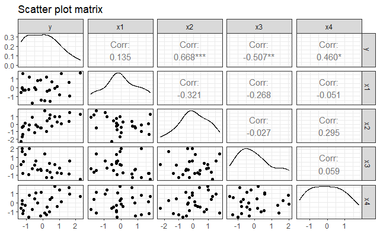

```r
Z %>%
  GGally::ggpairs(data = ., title = "Scatter plot matrix") +
  ggplot2::theme_bw()
```

**design matrix**

```r
X <-
  unname(stats::model.matrix(object = y ~ 1 + x1 + x2 + x3 + x4,
                             data = Z))
attr(x = X, which = "assign") <- NULL
head(x = X)
```

```
     [,1]        [,2]        [,3]       [,4]      [,5]
[1,]    1 -0.06515604  0.96924866  0.2078288 1.7965226
[2,]    1  0.63232937  0.38762530 -0.8870740 1.6752573
[3,]    1 -0.82464016  1.01976524 -0.2027598 1.4327267
[4,]    1 -1.46012687 -0.52258340 -0.4764855 1.1901962
[5,]    1 -0.20465313 -0.09266149  0.5773585 1.0689309
[6,]    1 -0.95638741  1.52538617  0.5773585 0.9476656
```

data list for Stan simulation

```r
dataList <-
  list(
    N = nrow(x = X),
    M = ncol(x = X),
    X = as.matrix(x = X),
    y = as.numeric(x = Z$y)
  )
rm(dat, X, Z)
```

### 3.1.2 Statistical model

**model parameters** $\boldsymbol{\beta}$ and $\sigma$

$$\text{Likelihood:} \qquad
\left.\boldsymbol{y}\right| \boldsymbol{X}, \boldsymbol{\beta},
\sigma^{2}, I
\stackrel{\mathrm{ind}}{\sim} \mathrm{N}(\mu, \sigma^{2}) \ ,
\qquad
\sigma^{2} := \mathrm{Var}\left(\left.\boldsymbol{y}\right|
\boldsymbol{X}, \boldsymbol{\beta}, I\right) = \text{constant}$$
$$\text{Linear model:} \qquad
\mu := \mathrm{E}\left(\left.\boldsymbol{y}\right| \boldsymbol{X},
\boldsymbol{\beta}, \sigma^{2}, I\right) =
\boldsymbol{X}\boldsymbol{\beta}$$
$$\text{Regularising fixed priors:} \qquad
\left.\boldsymbol{\beta} \right| \sigma^{2}, I
\sim \mathrm{N}(0, 1) \ ,
\qquad \left.\sigma\right| I
\sim \mathrm{Exp}(1)$$

### 3.1.3 Fitting a Stan model: Gauß likelihood and regularising fixed priors

```r
stanLinRegNormFixed <-
  rstan::stan(
    file = "linRegNormFixed.stan",
    data = dataList,
    chains = 4,
    iter = 2000,
    warmup = 1000,
    thin = 1,
    init = "random",
    algorithm = "NUTS",
    control = list(adapt_delta = 0.99,
                   max_treedepth = 15),
    cores = 3
  )
```

See also the Stan User’s Guide (Version 2.30), Sec. 1.1, URL (cited on August 19, 2022): https://mc-stan.org/docs/stan-users-guide/linear-regression.html.

### 3.1.4 HMC diagnostics

```r
rstan::check_hmc_diagnostics(object = stanLinRegNormFixed)
```

```
Divergences:
```

```
0 of 4000 iterations ended with a divergence.
```

```
Tree depth:
```

```
0 of 4000 iterations saturated the maximum tree depth of 15.
```

```
Energy:
```

```
E-BFMI indicated no pathological behavior.
```

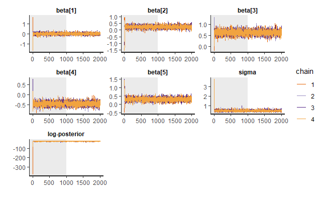

```r
rstan::stan_trace(
  object = stanLinRegNormFixed,
  pars = c("beta", "sigma", "lp__"),
  inc_warmup = TRUE
)
```

### 3.1.5 Summary of posterior marginal probability distributions for model parameters

```r
print(
  x = stanLinRegNormFixed,
  pars = c("beta", "sigma", "lp__"),
  probs = c(0.015, 0.25, 0.50, 0.75, 0.985)
)
```

```
Inference for Stan model: anon_model.
4 chains, each with iter=2000; warmup=1000; thin=1;
post-warmup draws per chain=1000, total post-warmup draws=4000.

          mean se_mean   sd   1.5%    25%    50%    75%  98.5% n_eff Rhat
beta[1]   0.00    0.00 0.09  -0.20  -0.06   0.00   0.06   0.20  3500    1
beta[2]   0.24    0.00 0.10   0.01   0.17   0.24   0.31   0.47  3333    1
beta[3]   0.64    0.00 0.10   0.41   0.57   0.64   0.71   0.87  3108    1
beta[4]  -0.44    0.00 0.10  -0.64  -0.50  -0.44  -0.38  -0.22  3664    1
beta[5]   0.31    0.00 0.10   0.09   0.24   0.31   0.37   0.53  3180    1
sigma     0.47    0.00 0.07   0.35   0.42   0.46   0.52   0.66  2390    1
lp__    -23.66    0.05 1.89 -28.97 -24.59 -23.32 -22.29 -20.96  1370    1

Samples were drawn using NUTS(diag_e) at Mon Aug 29 23:18:10 2022.
For each parameter, n_eff is a crude measure of effective sample size,
and Rhat is the potential scale reduction factor on split chains (at
convergence, Rhat=1).
```

```
ci_level: 0.89 (89% intervals)
outer_level: 0.97 (97% intervals)
```

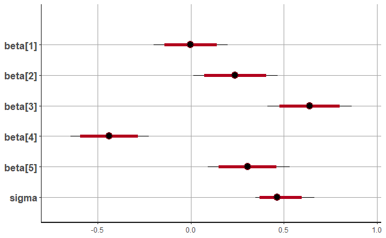

```r
rstan::stan_plot(
  object = stanLinRegNormFixed,
  pars = c("beta", "sigma"),
  ci_level = 0.89,
  outer_level = 0.97
)
```

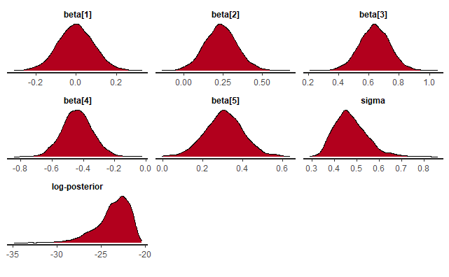

```r
rstan::stan_dens(object = stanLinRegNormFixed,
                 pars = c("beta", "sigma", "lp__"))
```

### 3.1.6 Posterior predictive checks

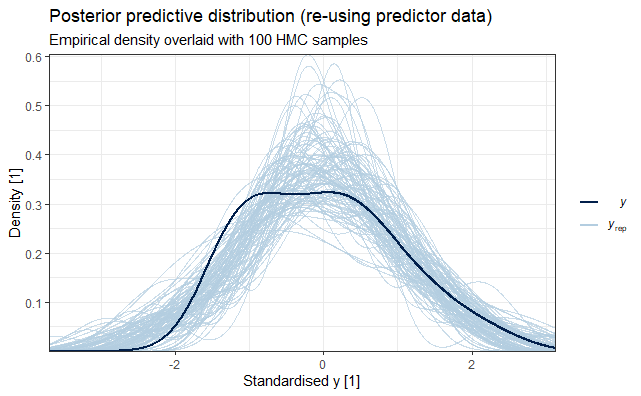

```r
draws <-
  as.matrix(x = stanLinRegNormFixed,
            pars = "yrep")

bayesplot::ppc_dens_overlay(y = dataList$y,
                            yrep = draws[501:600,]) +
  ggplot2::labs(
    title = paste0(
      "Posterior predictive distribution ",
      "(re-using predictor data)"
    ),
    subtitle = "Empirical density overlaid with 100 HMC samples"
  ) +
  ggplot2::xlab(label = "Standardised y [1]") +
  ggplot2::ylab(label = "Density [1]") +
  ggplot2::theme_bw()
```

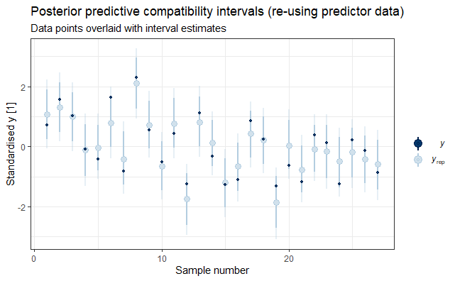

```r
bayesplot::ppc_intervals(
  y = dataList$y,
  yrep = draws,
  prob = 0.89,
  prob_outer = 0.97,
  size = 1,
  fatten = 3
) +
  ggplot2::labs(
    title = paste0(
      "Posterior predictive compatibility intervals ",
      "(re-using predictor data)"
    ),
    subtitle = "Data points overlaid with interval estimates"
  ) +
  ggplot2::xlab(label = "Sample number") +
  ggplot2::ylab(label = "Standardised y [1]") +
  ggplot2::theme_bw()
```

### 3.1.7 Analysis of residuals

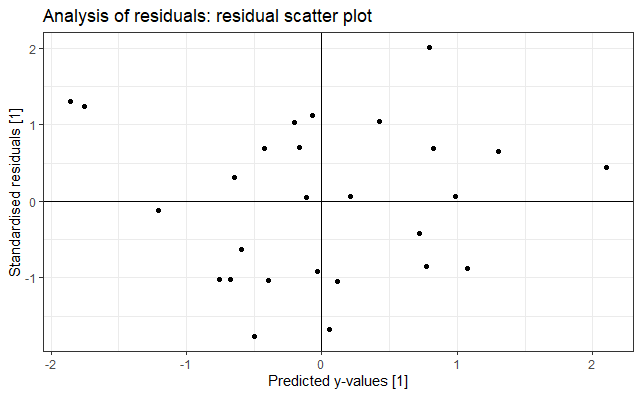

```r
tibble::tibble(
  predicted = draws %>%
    tibble::as_tibble(x = .) %>%
    purrr::map_dbl(.x = ., .f = mean, na.rm = TRUE),
  observed = dataList$y
) %>%
  dplyr::mutate(.data = .,
                residuals = (observed - predicted)) %>%
  dplyr::mutate(
    .data = .,
    residuals_std = scale(x = residuals,
                          center = TRUE,
                          scale = TRUE) %>%
      as.numeric(x = .)
  ) %>%
  ggplot2::ggplot(data = .,
         mapping = aes(x = predicted, y = residuals_std)) +
  ggplot2::geom_point() +
  ggplot2::geom_hline(yintercept = 0, size = 0.4) +
  ggplot2::geom_vline(xintercept = 0, size = 0.4) +
  ggplot2::labs(title = "Analysis of residuals: residual scatter plot") +
  ggplot2::xlab(label = "Predicted y-values [1]") +
  ggplot2::ylab(label = "Standardised residuals [1]") +
  ggplot2::theme_bw()
```

### 3.1.8 Remarks

clear data

```r
rm(dataList, draws, stanLinRegNormFixed)
```

## 3.2 ANOVA-like regression

### 3.2.1 Data and visualisation

**data set** `massMonitoring.csv`

```r
dat <-
  utils::read.csv(file = "massMonitoring.csv") %>%
  tibble::as_tibble(x = .)
any(is.na(x = dat))
dim(x = dat)
head(x = dat)
```

**variables**

`y`: body mass [kg] (`X1`)

`gp`: year of observation (`X2`)

**visualisation**

```r
dat %>%
  ggplot2::ggplot(data = ., mapping = aes(x = as.factor(x = X2), y = X1)) +
  ggplot2::geom_boxplot() +
  ggplot2::xlab(label = "Year of observation") +
  ggplot2::ylab(label = "Body mass [kg]") +
  ggplot2::theme_bw()
```

data list for Stan simulation

```r
dataList <-
  list(
    N = as.integer(x = nrow(x = dat)),
    K = length(x = unique(x = dat$X2)),
    gp = dat$X2,
    y = dat$X1
  )
rm(dat)
```

### 3.2.2 Statistical model

**model parameters** $\boldsymbol{\mu}[gp]$ and $\sigma$

$$\text{Likelihood:} \qquad
\left.\boldsymbol{y}\right| \boldsymbol{\mu},
\sigma^{2}, [gp], I
\stackrel{\mathrm{ind}}{\sim} \mathrm{N}(\boldsymbol{\mu}[gp],
\sigma^{2}) \ ,
\qquad
\sigma^{2} := \mathrm{Var}\left(\left.\boldsymbol{y}\right| I\right) =
\text{constant}$$
$$\text{Fixed priors:} \qquad
\left.\boldsymbol{\mu}[gp] \right| \sigma^{2}, I
\sim \mathrm{N}(90~\mathrm{kg}, (2~\mathrm{kg})^{2}) \ ,
\qquad \left.\sigma\right| I
\sim \mathrm{Exp}(1)$$

### 3.2.3 Fitting a Stan model: Gauß likelihood, homogeneous variances and fixed priors

```r
stanAnovaRegNormFixed <-
  rstan::stan(
    file = "anovaRegNormFixed.stan",
    data = dataList,
    chains = 4,
    iter = 2000,
    warmup = 1000,
    thin = 1,
    init = "random",
    algorithm = "NUTS",
    control = list(adapt_delta = 0.99,
                   max_treedepth = 15),
    cores = 3
  )
```

### 3.2.4 HMC diagnostics

```r
rstan::check_hmc_diagnostics(object = stanAnovaRegNormFixed)
rstan::stan_trace(
  object = stanAnovaRegNormFixed,
  pars = c("mu", "sigma", "lp__"),
  inc_warmup = TRUE
)
```

### 3.2.5 Summary of posterior marginal probability distributions for model parameters

```r
print(
  x = stanAnovaRegNormFixed,
  pars = c("mu", "sigma", "lp__"),
  probs = c(0.015, 0.25, 0.50, 0.75, 0.985)
)
rstan::stan_plot(
  object = stanAnovaRegNormFixed,
  pars = c("mu"),
  ci_level = 0.89,
  outer_level = 0.97
)
rstan::stan_plot(
  object = stanAnovaRegNormFixed,
  pars = c("sigma"),
  ci_level = 0.89,
  outer_level = 0.97
)
rstan::stan_dens(object = stanAnovaRegNormFixed,
                 pars = c("mu", "sigma", "lp__"))
```

### 3.2.6 Posterior predictive checks

```r
draws <-
  as.matrix(x = stanAnovaRegNormFixed,
            pars = "yrep")

bayesplot::ppc_dens_overlay(y = dataList$y,
                            yrep = draws[501:600,]) +
  ggplot2::labs(
    title = paste0(
      "Posterior predictive distribution ",
      "(re-using predictor data)"
    ),
    subtitle = "Empirical density overlaid with 100 HMC samples"
  ) +
  ggplot2::xlab(label = "y [kg]") +
  ggplot2::ylab(label = "Density [1/kg]") +
  ggplot2::theme_bw()

bayesplot::ppc_intervals_grouped(
  y = dataList$y,
  yrep = draws,
  group = dataList$gp,
  prob = 0.89,
  prob_outer = 0.97,
  size = 1,
  fatten = 3
) +
  ggplot2::labs(
    title = paste0(
      "Posterior predictive compatibility intervals ",
      "(re-using predictor data)"
    ),
    subtitle = "Data points overlaid with interval estimates"
  ) +
  ggplot2::xlab(label = "Sample number") +
  ggplot2::ylab(label = "y [kg]") +
  ggplot2::theme_bw()
```

### 3.2.7 Remarks

clear data

```r
rm(dataList, draws, stanAnovaRegNormFixed)
```

## 3.3 Logistic regression

### 3.3.1 Data and visualisation

**data set** `urine` from R package `boot` by Canty and Ripley (2021); type `?urine`.

```r
library(boot)
data("urine")
attach(what = urine)
any(is.na(x = urine)) # Checking for missing values in the data matrix
dat <-
  stats::na.omit(object = urine) %>% # Delete cases with missing values
  tibble::as_tibble(x = .)
rm(urine)
dim(x = dat)
head(x = dat)
```

**visualisation** (suppressing five independent variables other than `urea`)

```r
dat %>%
  ggplot2::ggplot(data = ., mapping = aes(x = urea, y = r)) +
  ggplot2::geom_point() +
  ggplot2::scale_x_continuous(name = paste0("Urea concentration ",
                                            "[millimoles per litre]")) +
  ggplot2::scale_y_continuous(
    name = "Presence of calcium oxalate crystals [1]",
    breaks = seq(from = 0, to = 1, by = 1),
    labels = scales::number_format(
      accuracy = 1,
      big.mark = ".",
      decimal.mark = ","
    )
  ) +
  ggplot2::theme_bw()
```

**standardisation** of **variables**

`y`: indicator of the presence of calcium oxalate crystals: {0, 1} (`r`)

`x1`: standardised specific gravity of the urine [1] (`gravity`)

`x2`: standardised pH reading of the urine [1] (`ph`)

`x3`: standardised osmolarity of the urine [milliosmoles per litre] (`osmo`)

`x4`: standardised conductivity of the urine [micro-Siemens per centimetre] (`cond`)

`x5`: standardised urea concentration [millimoles per litre] (`urea`)

`x6`: standardised calcium concentration [millimoles per litre] (`calc`)

```r
Z <-
  scale(x = dat[, 2:7],
        center = TRUE,
        scale = TRUE) %>%
  magrittr::set_colnames(x = .,
                         value = c("x1", "x2", "x3", "x4", "x5", "x6")) %>%
  tibble::as_tibble(x = .)
head(x = Z)
```

**design matrix**

```r
X <-
  unname(stats::model.matrix(object = dat$r ~ 1 + x1 + x2 + x3 + x4 + x5 + x6,
                             data = Z))
attr(x = X, which = "assign") <- NULL
head(x = X)
```

data list for Stan simulation

```r
dataList <-
  list(
    N = nrow(x = X),
    M = ncol(x = X),
    X = as.matrix(x = X),
    y = as.integer(x = dat$r)
  )
rm(dat, X, Z)
```

### 3.3.2 Statistical model

**model parameters** $\boldsymbol{\beta}$

$$\text{Likelihood:} \qquad
\left.\boldsymbol{y}\right| \boldsymbol{X}, \boldsymbol{\beta}, I
\stackrel{\mathrm{ind}}{\sim} \mathrm{Bern}(p)$$
$$\text{Linear model:} \qquad
\text{logit}(p) := \ln\left(\frac{p}{1-p}\right)
= \boldsymbol{X}\boldsymbol{\beta}$$
$$\text{Regularising fixed priors:} \qquad
\left.\boldsymbol{\beta} \right| I
\sim \mathrm{N}(0, 1)$$

### 3.3.3 Fitting a Stan model: Bernoulli likelihood with logit link and regularising fixed priors

```r
stanLogistRegBernFixed <-
  rstan::stan(
    file = "logistRegBernFixed.stan",
    data = dataList,
    chains = 4,
    iter = 2000,
    warmup = 1000,
    thin = 1,
    init = "random",
    algorithm = "NUTS",
    control = list(adapt_delta = 0.99,
                   max_treedepth = 15),
    cores = 3
  )
```

See also the Stan User’s Guide (Version 2.30), Sec. 1.5, URL (cited on August 19, 2022): https://mc-stan.org/docs/stan-users-guide/logistic-probit-regression.html.

### 3.3.4 HMC diagnostics

```r
rstan::check_hmc_diagnostics(object = stanLogistRegBernFixed)
rstan::stan_trace(
  object = stanLogistRegBernFixed,
  pars = c("beta", "lp__"),
  inc_warmup = TRUE
)
```

### 3.3.5 Summary of posterior marginal probability distributions for model parameters

```r
print(
  x = stanLogistRegBernFixed,
  pars = c("beta", "lp__"),
  probs = c(0.015, 0.25, 0.50, 0.75, 0.985)
)
rstan::stan_plot(
  object = stanLogistRegBernFixed,
  pars = c("beta"),
  ci_level = 0.89,
  outer_level = 0.97
)
rstan::stan_dens(object = stanLogistRegBernFixed,
                 pars = c("beta", "lp__"))
```

### 3.3.6 Posterior predictive checks

```r
draws <-
  as.matrix(x = stanLogistRegBernFixed,
            pars = "yrep")

bayesplot::ppc_dens_overlay(y = dataList$y,
                            yrep = draws[501:600,]) +
  ggplot2::labs(
    title = paste0(
      "Posterior predictive distribution ",
      "(re-using predictor data)"
    ),
    subtitle = "Empirical density overlaid with 100 HMC samples"
  ) +
  ggplot2::xlab(label = "y [1]") +
  ggplot2::ylab(label = "Density [1]") +
  ggplot2::theme_bw()

bayesplot::ppc_intervals(
  y = dataList$y,
  yrep = draws,
  prob = 0.89,
  prob_outer = 0.97,
  size = 1,
  fatten = 3
) +
  ggplot2::labs(
    title = paste0(
      "Posterior predictive compatibility intervals ",
      "(re-using predictor data)"
    ),
    subtitle = "Data points overlaid with interval estimates"
  ) +
  ggplot2::xlab(label = "Sample number") +
  ggplot2::ylab(label = "y [1]") +
  ggplot2::theme_bw()
```

### 3.3.7 Remarks

clear data

```r
rm(dataList, draws, stanLogistRegBernFixed)
```

## 3.4 Poisson regression

### 3.4.1 Data and visualisation

**data set** `poissonData.RData`

```r
load("poissonData.RData")
attach(what = poissonData)
any(is.na(x = poissonData)) # Checking for missing values in the data matrix
dat <-
  stats::na.omit(object = poissonData) %>% # Delete cases with missing values
  tibble::as_tibble(x = .)
rm(poissonData)
dim(x = dat)
head(x = dat)
```

**visualisation**

```r
dat %>%
  ggplot2::ggplot(data = ., mapping = aes(x = y)) +
  ggplot2::geom_bar(mapping = aes(y = ..prop..),
                    stat = "count",
                    width = 0.1) +
  ggplot2::scale_x_continuous(
    name = "Count per 15 min observation interval [1]",
    breaks = seq(from = 0, to = 8, by = 1),
    labels = scales::number_format(
      accuracy = 1,
      big.mark = ".",
      decimal.mark = ","
    )
  ) +
  ggplot2::scale_y_continuous(
    name = "Relative frequency [1]",
    labels = scales::percent) +
  ggplot2::theme_bw()
```

**standardisation** of **variables**

`y`: count of planes touching down inside of a 15 min observation interval [1]

`x1`: standardised start of 15 min observation interval [h]

`x2`: standardised estimated Beaufort wind force scale number [1]

`x3`: standardised wind direction [1]

`gp`: day-of-week ID: Monday (`1`) to Sunday (`7`)

```r
Z <-
  scale(x = dat[, 2:4],
        center = TRUE,
        scale = TRUE) %>%
  magrittr::set_colnames(x = ., value = c("x1", "x2", "x3")) %>%
  tibble::as_tibble(x = .)
head(x = Z)
```

**design matrix**

```r
X <-
  unname(stats::model.matrix(object = dat$y ~ 1 + x1 + x2 + x3,
                             data = Z))
attr(x = X, which = "assign") <- NULL
head(x = X)
```

data list for Stan simulation

```r
dataList <-
  list(
    N = nrow(x = X),
    M = ncol(x = X),
    X = X,
    y = dat$y
  )
rm(dat, X, Z)
```

### 3.4.2 Statistical model

**model parameters** $\boldsymbol{\beta}$

$$\text{Likelihood:} \qquad
\left.\boldsymbol{y}\right| \boldsymbol{X}, \boldsymbol{\beta}, I
\stackrel{\mathrm{ind}}{\sim} \mathrm{Pois}(\theta)$$
$$\text{Linear model:} \qquad
\ln\left(\theta\right)
= \boldsymbol{X}\boldsymbol{\beta}$$
$$\text{Regularising fixed priors:} \qquad
\left.\boldsymbol{\beta} \right| I
\sim \mathrm{N}(0, 1)$$

### 3.4.3 Fitting a Stan model: Poisson likelihood with log link and regularising fixed priors

```r
stanPoisRegFixed <-
  rstan::stan(
    file = "poisRegFixed.stan",
    data = dataList,
    chains = 4,
    iter = 2000,
    warmup = 1000,
    thin = 1,
    init = "random",
    algorithm = "NUTS",
    control = list(adapt_delta = 0.99,
                   max_treedepth = 15),
    cores = 3
  )
```

### 3.4.4 HMC diagnostics

```r
rstan::check_hmc_diagnostics(object = stanPoisRegFixed)
rstan::stan_trace(
  object = stanPoisRegFixed,
  pars = c("beta", "lp__"),
  inc_warmup = TRUE
)
```

### 3.4.5 Summary of posterior marginal probability distributions for model parameters

```r
print(
  x = stanPoisRegFixed,
  pars = c("beta", "lp__"),
  probs = c(0.015, 0.25, 0.50, 0.75, 0.985)
)
rstan::stan_plot(
  object = stanPoisRegFixed,
  pars = c("beta"),
  ci_level = 0.89,
  outer_level = 0.97
)
rstan::stan_dens(object = stanPoisRegFixed,
                 pars = c("beta", "lp__"))
```

### 3.4.6 Posterior predictive checks

```r
draws <-
  as.matrix(x = stanPoisRegFixed,
            pars = "yrep")

bayesplot::ppc_dens_overlay(y = dataList$y,
                            yrep = draws[501:600,]) +
  ggplot2::labs(
    title = paste0(
      "Posterior predictive distribution ",
      "(re-using predictor data)"
    ),
    subtitle = "Empirical density overlaid with 100 HMC samples"
  ) +
  ggplot2::ylab(label = "Density [1]") +
  ggplot2::scale_x_continuous(
    name = "y [1]",
    breaks = seq(from = 0, to = 8, by = 1),
    labels = scales::number_format(
      accuracy = 1,
      big.mark = ".",
      decimal.mark = ","
    )
  ) +
  ggplot2::theme_bw()

bayesplot::ppc_intervals(
  y = dataList$y,
  yrep = draws,
  prob = 0.89,
  prob_outer = 0.97,
  size = 1,
  fatten = 3
) +
  ggplot2::labs(
    title = paste0(
      "Posterior predictive compatibility intervals ",
      "(re-using predictor data)"
    ),
    subtitle = "Data points overlaid with interval estimates"
  ) +
  ggplot2::xlab(label = "Sample number") +
  ggplot2::ylab(label = "y [1]") +
  ggplot2::theme_bw()

bayesplot::ppc_rootogram(
  y = dataList$y,
  yrep = draws,
  style = "standing",
  prob = 0.89,
  size = 1
) +
  ggplot2::labs(title = "Rootogram") +
  ggplot2::theme_bw()
```

### 3.4.7 Remarks

clear data

```r
rm(dataList, draws, stanPoisRegFixed)
```

## 3.5 Exponential regression

### 3.5.1 Data and visualisation

**data set** `tramWait.RData`

```r
load("tramWait.RData")
attach(what = tramWait)
any(is.na(x = tramWait)) # Checking for missing values in the data matrix
dat <-
  stats::na.omit(object = tramWait) %>%  # Delete cases with missing values
  tibble::as_tibble(x = .)
rm(tramWait)
dim(x = dat)
head(x = dat)
```

**standardisation** of **variables**

`y`: waiting time for tram to arrive at stop [min] (`wait`)

`x1`: standardised number of tram conductors available on tram line on day of observation [1] (`conductors`)

`x2`: standardised number of passengers having left or entered tram at previous stops [1] (`passChanged`)

`gp`: tram line number (`1` to `10`) (`tram`)

```r
Z <-
  scale(x = dat[, 2:3],
        center = TRUE,
        scale = TRUE) %>%
  magrittr::set_colnames(x = ., value = c("x1", "x2")) %>%
  tibble::as_tibble(x = .)
head(x = Z)
```

**design matrix**

```r
X <-
  unname(stats::model.matrix(object = dat$wait ~ 1 + x1 + x2,
                             data = Z))
attr(x = X, which = "assign") <- NULL
head(x = X)
```

data list for Stan simulation

```r
dataList <-
  list(
    N = nrow(x = X),
    M = ncol(x = X),
    X = X,
    y = dat$wait
  )
rm(dat, X, Z)
```

### 3.5.2 Statistical model

**model parameters** $\boldsymbol{\beta}$

$$\text{Likelihood:} \qquad
\left.\boldsymbol{y}\right| \boldsymbol{X}, \boldsymbol{\beta}, I
\stackrel{\mathrm{ind}}{\sim} \mathrm{Exp}(\theta)$$
$$\text{Linear model:} \qquad
\ln\left(\theta/\theta_{0}\right)
= \boldsymbol{X}\boldsymbol{\beta}$$
$$\text{Regularising fixed priors:} \qquad
\left.\boldsymbol{\beta} \right| I
\sim \mathrm{N}(0, 1)$$

### 3.5.3 Fitting a Stan model: Exponential likelihood with log link and regularising fixed priors

```r
stanExpRegFixed <-
  rstan::stan(
    file = "expRegFixed.stan",
    data = dataList,
    chains = 4,
    iter = 2000,
    warmup = 1000,
    thin = 1,
    init = "random",
    algorithm = "NUTS",
    control = list(adapt_delta = 0.99,
                   max_treedepth = 15),
    cores = 3
  )
```

### 3.5.4 HMC diagnostics

```r
rstan::check_hmc_diagnostics(object = stanExpRegFixed)
rstan::stan_trace(
  object = stanExpRegFixed,
  pars = c("beta", "lp__"),
  inc_warmup = TRUE
)
```

### 3.5.5 Summary of posterior marginal probability distributions for model parameters

```r
print(
  x = stanExpRegFixed,
  pars = c("beta", "lp__"),
  probs = c(0.015, 0.25, 0.50, 0.75, 0.985)
)
rstan::stan_plot(
  object = stanExpRegFixed,
  pars = c("beta"),
  ci_level = 0.89,
  outer_level = 0.97
)
rstan::stan_dens(object = stanExpRegFixed,
                 pars = c("beta", "lp__"))
```

### 3.5.6 Posterior predictive checks

```r
draws <-
  as.matrix(x = stanExpRegFixed,
            pars = "yrep")

bayesplot::ppc_dens_overlay(y = dataList$y,
                            yrep = draws[501:600,]) +
  ggplot2::labs(
    title = paste0(
      "Posterior predictive distribution ",
      "(re-using predictor data)"
    ),
    subtitle = "Empirical density overlaid with 100 HMC samples"
  ) +
  ggplot2::xlab(label = "y [min]") +
  ggplot2::ylab(label = "Density [1/min]") +
  ggplot2::theme_bw()

bayesplot::ppc_intervals(
  y = dataList$y,
  yrep = draws,
  prob = 0.89,
  prob_outer = 0.97,
  size = 1,
  fatten = 3
) +
  ggplot2::labs(
    title = paste0(
      "Posterior predictive compatibility intervals ",
      "(re-using predictor data)"
    ),
    subtitle = "Data points overlaid with interval estimates"
  ) +
  ggplot2::xlab(label = "Sample number") +
  ggplot2::ylab(label = "y [min]") +
  ggplot2::theme_bw()
```

### 3.5.7 Remarks

clear data

```r
rm(dataList, draws, stanExpRegFixed)
```

# 4 Varying effects generalised linear models

## 4.1 Multi-level linear regression

### 4.1.1 Data and visualisation

**data set** `iris` from R package `datasets` by the R Core Team (2022); type `?iris`.

```r
data("iris")
attach(what = iris)
any(is.na(x = iris)) # Checking for missing values in the data matrix
dat <-
  stats::na.omit(object = iris) %>% # Delete cases with missing values
  tibble::as_tibble(x = .) %>%
  dplyr::group_by(.data = ., Species) %>%
  dplyr::mutate(.data = ., gp = dplyr::cur_group_id()) %>% # Create group index
  dplyr::ungroup(x = .)
rm(iris)
dim(x = dat)
head(x = dat)
```

**visualisation** (variables `Sepal.Width` and `Petal.Length` suppressed)

```r
dat %>%
  ggplot2::ggplot(data = ., mapping = aes(x = Sepal.Length, y = Petal.Width)) +
  ggplot2::geom_point() +
  ggplot2::facet_wrap(facets = ~ Species) +
  ggplot2::scale_x_continuous(name = "Sepal length [cm]") +
  ggplot2::scale_y_continuous(name = "Petal width [cm]") +
  ggplot2::theme_bw()
```

**standardisation** of **variables**

`y`: standardised petal width [cm] (`Petal.Width`)

`x1`: standardised sepal length [cm] (`Sepal.Length`)

`x2`: standardised sepal width [cm] (`Sepal.Width`)

`x3`: standardised petal length [cm] (`Petal.Length`)

`gp`: group index: `1` (`setosa`), `2` (`versicolor`), `3` (`virginica`)

```r
Z <-
  scale(x = dat[, 1:4],
        center = TRUE,
        scale = TRUE) %>%
  magrittr::set_colnames(x = ., value = c("x1", "x2", "x3", "y")) %>%
  tibble::as_tibble(x = .)
head(x = Z)
```

**design matrix**

```r
X <-
  unname(stats::model.matrix(object = y ~ 1 + x1 + x2 + x3,
                             data = Z))
attr(x = X, which = "assign") <- NULL
head(x = X)
```

data list for Stan simulation

```r
dataList <-
  list(
    N = nrow(x = X),
    M = ncol(x = X),
    K = length(x = unique(x = dat$gp)),
    L = 1L,
    u = matrix(
      data = rep(1.0, length(x = unique(x = dat$gp))),
      nrow = length(x = unique(x = dat$gp)),
      ncol = 1L
    ),
    X = X,
    y = as.numeric(x = Z$y),
    gp = dat$gp
  )
rm(dat, X, Z)
```

### 4.1.2 Statistical model

**model parameters** $\boldsymbol{\gamma}_{\boldsymbol{\beta}}[gp]$, $\boldsymbol{\sigma}_{\boldsymbol{\beta}}[gp]$, $\boldsymbol{L}_{\boldsymbol{R}_{\boldsymbol{\beta}}}$, $\boldsymbol{z}_{\boldsymbol{\beta}}[gp]$ and $\sigma$.

$$\text{Likelihood:} \qquad
\left.\boldsymbol{y}\right| \boldsymbol{X}, \boldsymbol{\beta},
\sigma^{2}, [gp], I
\stackrel{\mathrm{ind}}{\sim} \mathrm{N}(
\boldsymbol{\mu}[gp], \sigma^{2}) \ ,
\qquad
\sigma^{2} := \mathrm{Var}\left(\left.\boldsymbol{y}\right|
\boldsymbol{X}, \boldsymbol{\beta}, [gp], I\right) = \text{constant}$$
$$\text{Linear model:} \qquad
\boldsymbol{\mu}[gp] := \mathrm{E}\left(\left.\boldsymbol{y}\right|
\boldsymbol{X},
\boldsymbol{\beta}, \sigma^{2}, [gp], I\right)
= \boldsymbol{X}[gp]\,\boldsymbol{\beta}[gp]$$
$$\text{Non-centred decomposition::} \qquad
\boldsymbol{\beta}[gp]
= \boldsymbol{u}\boldsymbol{\gamma}_{\boldsymbol{\beta}}[gp]
+ \text{diag}(\boldsymbol{\sigma}_{\boldsymbol{\beta}}[gp])\,
\boldsymbol{L}_{\boldsymbol{R}_{\boldsymbol{\beta}}}\,
\boldsymbol{z}_{\boldsymbol{\beta}}[gp]$$
$$\text{Regularising fixed priors:} \qquad
\left.\boldsymbol{\gamma}_{\boldsymbol{\beta}}[gp]
\right|\sigma^{2}, I
\sim \mathrm{N}(0, 1) \ ,
\qquad
\left.\boldsymbol{\sigma}_{\boldsymbol{\beta}}[gp]
\right|\sigma^{2}, I
\sim \mathrm{Exp}(1) \ ,
\qquad
\left.\boldsymbol{L}_{\boldsymbol{R}_{\boldsymbol{\beta}}}
\right|\sigma^{2}, I
\sim \mathrm{LKJ}(2) \ ,
\qquad
\left.\boldsymbol{z}_{\boldsymbol{\beta}}[gp]\right|\sigma^{2}, I
\sim \mathrm{N}(0, 1) \ ,
\qquad
\left.\sigma\right| I
\sim \mathrm{Exp}(1)$$

### 4.1.3 Fitting a Stan model: Gauß likelihood and adaptive priors (non-centred parametrisation)

```r
stanLinRegNormVarying <-
  rstan::stan(
    file = "linRegNormVarying.stan",
    data = dataList,
    chains = 4,
    iter = 2000,
    warmup = 1000,
    thin = 1,
    init = "random",
    algorithm = "NUTS",
    control = list(adapt_delta = 0.99,
                   max_treedepth = 15),
    cores = 3
  )
```

See also the Stan User’s Guide (Version 2.30), Sec. 1.13, URL (cited on August 20, 2022): https://mc-stan.org/docs/stan-users-guide/multivariate-hierarchical-priors.html.

### 4.1.4 HMC diagnostics

```r
rstan::check_hmc_diagnostics(object = stanLinRegNormVarying)
rstan::stan_trace(
  object = stanLinRegNormVarying,
  pars = c("beta", "R_beta", "sigma", "lp__"),
  inc_warmup = TRUE
)
```

### 4.1.5 Summary of posterior marginal probability distributions for model parameters

**No** densities displayed for reasons of space.

```r
print(
  x = stanLinRegNormVarying,
  pars = c("beta", "R_beta", "sigma", "lp__"),
  probs = c(0.015, 0.25, 0.50, 0.75, 0.985)
)
rstan::stan_plot(
  object = stanLinRegNormVarying,
  pars = c("beta", "sigma"),
  ci_level = 0.89,
  outer_level = 0.97
)
rstan::stan_plot(
  object = stanLinRegNormVarying,
  pars = c("R_beta"),
  ci_level = 0.89,
  outer_level = 0.97
)
```

### 4.1.6 Posterior predictive checks

```r
draws <-
  as.matrix(x = stanLinRegNormVarying,
            pars = "yrep")

bayesplot::ppc_dens_overlay(y = dataList$y,
                            yrep = draws[501:600, ]) +
  ggplot2::labs(
    title = paste0(
      "Posterior predictive distribution ",
      "(re-using predictor data)"
    ),
    subtitle = "Empirical density overlaid with 100 HMC samples"
  ) +
  ggplot2::xlab(label = "Standardised y [1]") +
  ggplot2::ylab(label = "Density [1]") +
  ggplot2::theme_bw()

bayesplot::ppc_intervals_grouped(
  y = dataList$y,
  yrep = draws,
  group = dataList$gp,
  prob = 0.89,
  prob_outer = 0.97,
  size = 1,
  fatten = 3
) +
  ggplot2::labs(
    title = paste0(
      "Posterior predictive compatibility intervals ",
      "(re-using predictor data)"
    ),
    subtitle = "Data points overlaid with interval estimates"
  ) +
  ggplot2::xlab(label = "Sample number") +
  ggplot2::ylab(label = "Standardised y [1]") +
  ggplot2::theme_bw()
```

### 4.1.7 Pareto-smoothed importance-sampling leave-one-out cross-validation (PSIS-LOO)

```r
looLinRegNormVarying <-
  loo::loo(x = stanLinRegNormVarying,
           pars = "log_lik")
print(x = looLinRegNormVarying)
plot(x = looLinRegNormVarying,
     label_points = TRUE)
```

### 4.1.8 Remarks

clear data

```r
rm(dataList, draws, stanLinRegNormVarying, looLinRegNormVarying)
```

## 4.2 Multi-level ANOVA-like regression

### 4.2.1 Data and visualisation

```r
dat <-
  utils::read.csv(file = "massMonitoring.csv") %>%
  tibble::as_tibble(x = .)
any(is.na(x = dat))
dim(x = dat)
head(x = dat)
```

data list for Stan simulation

```r
dataList <-
  list(
    N = as.integer(x = nrow(x = dat)),
    K = length(x = unique(x = dat$X2)),
    gp = dat$X2,
    y = dat$X1
  )
rm(dat)
```

### 4.2.2 Statistical model

**model parameters** $\boldsymbol{\mu}[gp]$ and $\boldsymbol{\sigma}[gp]$

$$\text{Likelihood:} \qquad
\left.\boldsymbol{y}\right| \boldsymbol{\mu},
\sigma^{2}, [gp], I
\stackrel{\mathrm{ind}}{\sim} \mathrm{N}(\boldsymbol{\mu}[gp],
\boldsymbol{\sigma}^{2}[gp])$$
$$\text{Adaptive priors:} \qquad
\boldsymbol{\mu}[gp]
\sim \mathrm{N}(\mu_{\mu}, \sigma_{\mu}^{2}) \ ,
\qquad
\boldsymbol{\sigma}[gp]
\sim \mathrm{Exp}(\beta_{\sigma})$$
$$\text{Weakly regularising fixed priors:} \qquad
\mu_{\mu}
\sim \mathrm{N}(90~\mathrm{kg}, (2~\mathrm{kg})^{2}) \ ,
\qquad
\sigma_{\mu}
\sim \mathrm{Exp}(1) \ ,
\qquad
\beta_{\sigma}
\sim \mathrm{Exp}(1)$$

### 4.2.3 Fitting a Stan model: Gauß likelihood, inhomogeneous variances and adaptive priors

```r
stanAnovaRegNormVarying <-
  rstan::stan(
    file = "anovaRegNormVarying.stan",
    data = dataList,
    chains = 4,
    iter = 2000,
    warmup = 1000,
    thin = 1,
    init = "random",
    algorithm = "NUTS",
    control = list(adapt_delta = 0.99,
                   max_treedepth = 15),
    cores = 3
  )
```

### 4.2.4 HMC diagnostics

```r
rstan::check_hmc_diagnostics(object = stanAnovaRegNormVarying)
rstan::stan_trace(
  object = stanAnovaRegNormVarying,
  pars = c("mu", "sigma", "lp__"),
  inc_warmup = TRUE
)
```

### 4.2.5 Summary of posterior marginal probability distributions for model parameters

```r
print(
  x = stanAnovaRegNormVarying,
  pars = c("mu", "sigma", "lp__"),
  probs = c(0.015, 0.25, 0.50, 0.75, 0.985)
)
rstan::stan_plot(
  object = stanAnovaRegNormVarying,
  pars = c("mu"),
  ci_level = 0.89,
  outer_level = 0.97
)
rstan::stan_plot(
  object = stanAnovaRegNormVarying,
  pars = c("sigma"),
  ci_level = 0.89,
  outer_level = 0.97
)
rstan::stan_dens(object = stanAnovaRegNormVarying,
                 pars = c("mu", "sigma", "lp__"))
```

### 4.2.6 Posterior predictive checks

```r
draws <-
  as.matrix(x = stanAnovaRegNormVarying,
            pars = "yrep")

bayesplot::ppc_dens_overlay(y = dataList$y,
                            yrep = draws[501:600,]) +
  ggplot2::labs(
    title = paste0(
      "Posterior predictive distribution ",
      "(re-using predictor data)"
    ),
    subtitle = "Empirical density overlaid with 100 HMC samples"
  ) +
  ggplot2::xlab(label = "y [kg]") +
  ggplot2::ylab(label = "Density [1/kg]") +
  ggplot2::theme_bw()

bayesplot::ppc_intervals_grouped(
  y = dataList$y,
  yrep = draws,
  group = dataList$gp,
  prob = 0.89,
  prob_outer = 0.97,
  size = 1,
  fatten = 3
) +
  ggplot2::labs(
    title = paste0(
      "Posterior predictive compatibility intervals ",
      "(re-using predictor data)"
    ),
    subtitle = "Data points overlaid with interval estimates"
  ) +
  ggplot2::xlab(label = "Sample number") +
  ggplot2::ylab(label = "y [kg]") +
  ggplot2::theme_bw()
```

### 4.2.7 Pareto-smoothed importance-sampling leave-one-out cross-validation (PSIS-LOO)

```r
looAnovaRegNormVarying <-
  loo::loo(x = stanAnovaRegNormVarying,
           pars = "log_lik")
print(x = looAnovaRegNormVarying)
plot(x = looAnovaRegNormVarying,
     label_points = TRUE)
```

### 4.2.8 Remarks

clear data

```r
rm(dataList, draws, stanAnovaRegNormVarying, looLinRegNormVarying)
```

## 4.3 Multi-level logistic regression

### 4.3.1 Data and visualisation

**data set** `bankloan.RData` (IBM SPSS tutorial binary logistic regression), URL (cited on August 21, 2022): https://www.ibm.com/support/knowledgecenter/en/SSLVMB_sub/statistics_casestudies_project_ddita/spss/tutorials/log_bankloan_intro.html.

```r
load("bankloan.RData")
attach(what = bankloan)
any(is.na(x = bankloan)) # Checking for missing values in the data matrix
dat <-
  stats::na.omit(object = bankloan) %>% # Delete cases with missing values
  tibble::as_tibble(x = .)
rm(bankloan)
dim(x = dat)
head(x = dat)
```

**standardisation** of **variables**

`y`: indicator of previous defaults: {0, 1} (`default`)

`x1`: standardised age [yr] (`age`)

`x2`: standardised years with current employer [yr] (`employ`)

`x3`: standardised years at current address [yr] (`address`)

`x4`: standardised household income [$ 10³] (`income`)

`x5`: standardised debt to income ratio [%] (`debtinc`)

`x6`: standardised credit card debt [$ 10³] (`creddebt`)

`x7`: standardised other debt [$ 10³] (`othdebt`)

`gp`: level of education: “did not complete high school” (`1`), “high school degree” (`2`), “some college” (`3`), “college degree” (`4`), “doctorate” (`5`) (`ed`)

```r
Z <-
  scale(x = dat[, c(1, 3:8)],
        center = TRUE,
        scale = TRUE) %>%
  magrittr::set_colnames(x = .,
                         value = c("x1", "x2", "x3", "x4", "x5",
                                   "x6", "x7")) %>%
  tibble::as_tibble(x = .)
head(x = Z)
```

**design matrix**

```r
X <-
  unname(stats::model.matrix(
    object = dat$default ~ 1 + x1 + x2 + x3 + x4 + x5 + x6 + x7,
    data = Z
  ))
attr(x = X, which = "assign") <- NULL
head(x = X)
```

data list for Stan simulation

```r
dataList <-
  list(
    N = nrow(x = X),
    M = ncol(x = X),
    K = length(x = unique(x = dat$ed)),
    L = 1L,
    u = matrix(
      data = rep(1.0, length(x = unique(x = dat$ed))),
      nrow = length(x = unique(x = dat$ed)),
      ncol = 1L
    ),
    X = X,
    y = as.integer(x = dat$default),
    gp = as.integer(x = dat$ed)
  )
rm(dat, X, Z)
```

### 4.3.2 Statistical model

**model parameters** $\boldsymbol{\gamma}_{\boldsymbol{\beta}}[gp]$, $\boldsymbol{\sigma}_{\boldsymbol{\beta}}[gp]$, $\boldsymbol{L}_{\boldsymbol{R}_{\boldsymbol{\beta}}}$ and $\boldsymbol{z}_{\boldsymbol{\beta}}[gp]$.

$$\text{Likelihood:} \qquad
\left.\boldsymbol{y}\right| \boldsymbol{X}, \boldsymbol{\beta}, [gp], I
\stackrel{\mathrm{ind}}{\sim} \mathrm{Bern}(p[gp])$$
$$\text{Linear model:} \qquad
\text{logit}(p)[gp] :=
\ln\left(\frac{p}{1-p}\right)[gp]
= \boldsymbol{X}[gp]\,\boldsymbol{\beta}[gp]$$
$$\text{Non-centred decomposition::} \qquad
\boldsymbol{\beta}[gp]
= \boldsymbol{u}\boldsymbol{\gamma}_{\boldsymbol{\beta}}[gp]
+ \text{diag}(\boldsymbol{\sigma}_{\boldsymbol{\beta}}[gp])\,
\boldsymbol{L}_{\boldsymbol{R}_{\boldsymbol{\beta}}}\,
\boldsymbol{z}_{\boldsymbol{\beta}}[gp]$$
$$\text{Regularising fixed priors:} \qquad
\left.\boldsymbol{\gamma}_{\boldsymbol{\beta}}[gp]\right| I
\sim \mathrm{N}(0, 1) \ ,
\qquad
\left.\boldsymbol{\sigma}_{\boldsymbol{\beta}}[gp]\right| I
\sim \mathrm{Exp}(1) \ ,
\qquad
\left.\boldsymbol{L}_{\boldsymbol{R}_{\boldsymbol{\beta}}}\right| I
\sim \mathrm{LKJ}(2) \ ,
\qquad
\left.\boldsymbol{z}_{\boldsymbol{\beta}}[gp]\right| I
\sim \mathrm{N}(0, 1)$$

### 4.3.3 Fitting a Stan model: Bernoulli likelihood with logit link and adaptive priors (non-centred parametrisation)

```r
stanLogistRegBernVarying <-
  rstan::stan(
    file = "logistRegBernVarying.stan",
    data = dataList,
    chains = 4,
    iter = 2000,
    warmup = 1000,
    thin = 1,
    init = "random",
    algorithm = "NUTS",
    control = list(adapt_delta = 0.99,
                   max_treedepth = 15),
    cores = 3
  )
```

See also the Stan User’s Guide (Version 2.30), Secs. 1.9 and 1.13, URLs (cited on August 21, 2022): https://mc-stan.org/docs/stan-users-guide/hierarchical-logistic-regression.html, https://mc-stan.org/docs/stan-users-guide/multivariate-hierarchical-priors.html.

### 4.3.4 HMC diagnostics

```r
rstan::check_hmc_diagnostics(object = stanLogistRegBernVarying)
rstan::stan_trace(
  object = stanLogistRegBernVarying,
  pars = c("beta", "lp__"),
  inc_warmup = TRUE
)
```

### 4.3.5 Summary of posterior marginal probability distributions for model parameters

**No** densities displayed for reasons of space.

```r
print(
  x = stanLogistRegBernVarying,
  pars = c("beta", "lp__"),
  probs = c(0.015, 0.25, 0.50, 0.75, 0.985)
)
rstan::stan_plot(
  object = stanLogistRegBernVarying,
  pars = c("beta"),
  ci_level = 0.89,
  outer_level = 0.97
)
```

### 4.3.6 Posterior predictive checks

```r
draws <-
  as.matrix(x = stanLogistRegBernVarying,
            pars = "yrep")

bayesplot::ppc_dens_overlay(y = dataList$y,
                            yrep = draws[501:600,]) +
  ggplot2::labs(
    title = paste0(
      "Posterior predictive distribution ",
      "(re-using predictor data)"
    ),
    subtitle = "Empirical density overlaid with 100 HMC samples"
  ) +
  ggplot2::xlab(label = "y [1]") +
  ggplot2::ylab(label = "Density [1]") +
  ggplot2::theme_bw()

bayesplot::ppc_intervals_grouped(
  y = dataList$y,
  yrep = draws,
  group = dataList$gp,
  prob = 0.89,
  prob_outer = 0.97,
  size = 1,
  fatten = 3
) +
  ggplot2::labs(
    title = paste0(
      "Posterior predictive compatibility intervals ",
      "(re-using predictor data)"
    ),
    subtitle = "Data points overlaid with interval estimates"
  ) +
  ggplot2::xlab(label = "Sample number") +
  ggplot2::ylab(label = "y [1]") +
  ggplot2::theme_bw()
```

### 4.3.7 Pareto-smoothed importance-sampling leave-one-out cross-validation (PSIS-LOO)

```r
looLogistRegBernVarying <-
  loo::loo(x = stanLogistRegBernVarying,
           pars = "log_lik")
print(x = looLogistRegBernVarying)
plot(x = looLogistRegBernVarying,
     label_points = TRUE)
```

### 4.3.8 Remarks

clear data

```r
rm(dataList, draws, stanLogistRegBernVarying, looLogistRegBernVarying)
```

## 4.4 Multi-level Poisson regression

### 4.4.1 Data and visualisation

```r
load("poissonData.RData")
attach(what = poissonData)
any(is.na(x = poissonData)) # Checking for missing values in the data matrix
dat <-
  stats::na.omit(object = poissonData) %>% # Delete cases with missing values
  tibble::as_tibble(x = .)
rm(poissonData)
dim(x = dat)
head(x = dat)
```

**visualisation**

```r
dat %>%
  ggplot2::ggplot(data = ., mapping = aes(x = y)) +
  ggplot2::geom_bar(mapping = aes(y = ..prop..),
                    stat = "count",
                    width = 0.1) +
  ggplot2::scale_x_continuous(
    name = "Count per 15 min observation interval [1]",
    breaks = seq(from = 0, to = 8, by = 1),
    labels = scales::number_format(
      accuracy = 1,
      big.mark = ".",
      decimal.mark = ","
    )
  ) +
  ggplot2::scale_y_continuous(
    name = "Relative frequency [1]",
    labels = scales::percent) +
  ggplot2::facet_wrap(facets = ~ gp) +
  ggplot2::theme_bw()
```

**standardisation**

```r
Z <-
  scale(x = dat[, 2:4],
        center = TRUE,
        scale = TRUE) %>%
  magrittr::set_colnames(x = ., value = c("x1", "x2", "x3")) %>%
  tibble::as_tibble(x = .)
head(x = Z)
```

**design matrix**

```r
X <-
  unname(stats::model.matrix(object = dat$y ~ 1 + x1 + x2 + x3,
                             data = Z))
attr(x = X, which = "assign") <- NULL
head(x = X)
```

data list for Stan simulation

```r
dataList <-
  list(
    N = nrow(x = X),
    M = ncol(x = X),
    K = length(x = unique(x = dat$gp)),
    L = 1L,
    u = matrix(
      data = rep(1.0, length(x = unique(x = dat$gp))),
      nrow = length(x = unique(x = dat$gp)),
      ncol = 1L
    ),
    X = X,
    y = as.integer(x = dat$y),
    gp = as.integer(x = dat$gp)
  )
rm(dat, X, Z)
```

### 4.4.2 Statistical model

**model parameters** $\boldsymbol{\gamma}_{\boldsymbol{\beta}}[gp]$, $\boldsymbol{\sigma}_{\boldsymbol{\beta}}[gp]$, $\boldsymbol{L}_{\boldsymbol{R}_{\boldsymbol{\beta}}}$ and $\boldsymbol{z}_{\boldsymbol{\beta}}[gp]$.

$$\text{Likelihood:} \qquad
\left.\boldsymbol{y}\right| \boldsymbol{X}, \boldsymbol{\beta}, [gp], I
\stackrel{\mathrm{ind}}{\sim} \mathrm{Pois}(\theta[gp])$$
$$\text{Linear model:} \qquad
\ln\left(\theta\right)[gp]
= \boldsymbol{X}[gp]\,\boldsymbol{\beta}[gp]$$
$$\text{Non-centred decomposition::} \qquad
\boldsymbol{\beta}[gp]
= \boldsymbol{u}\boldsymbol{\gamma}_{\boldsymbol{\beta}}[gp]
+ \text{diag}(\boldsymbol{\sigma}_{\boldsymbol{\beta}}[gp])\,
\boldsymbol{L}_{\boldsymbol{R}_{\boldsymbol{\beta}}}\,
\boldsymbol{z}_{\boldsymbol{\beta}}[gp]$$
$$\text{Regularising fixed priors:} \qquad
\left.\boldsymbol{\gamma}_{\boldsymbol{\beta}}[gp]\right| I
\sim \mathrm{N}(0, 1) \ ,
\qquad
\left.\boldsymbol{\sigma}_{\boldsymbol{\beta}}[gp]\right| I
\sim \mathrm{Exp}(1) \ ,
\qquad
\left.\boldsymbol{L}_{\boldsymbol{R}_{\boldsymbol{\beta}}}\right| I
\sim \mathrm{LKJ}(2) \ ,
\qquad
\left.\boldsymbol{z}_{\boldsymbol{\beta}}[gp]\right| I
\sim \mathrm{N}(0, 1)$$

### 4.4.3 Fitting a Stan model: Poisson likelihood with log link and adaptive priors (non-centred parametrisation)

```r
stanPoisRegVarying <-
  rstan::stan(
    file = "poisRegVarying.stan",
    data = dataList,
    chains = 4,
    iter = 2000,
    warmup = 1000,
    thin = 1,
    init = "random",
    algorithm = "NUTS",
    control = list(adapt_delta = 0.99,
                   max_treedepth = 15),
    cores = 3
  )
```

### 4.4.4 HMC diagnostics

```r
rstan::check_hmc_diagnostics(object = stanPoisRegVarying)
rstan::stan_trace(
  object = stanPoisRegVarying,
  pars = c("beta", "lp__"),
  inc_warmup = TRUE
)
```

### 4.4.5 Summary of posterior marginal probability distributions for model parameters

**No** densities displayed for reasons of space.

```r
print(
  x = stanPoisRegVarying,
  pars = c("beta", "lp__"),
  probs = c(0.015, 0.25, 0.50, 0.75, 0.985)
)
rstan::stan_plot(
  object = stanPoisRegVarying,
  pars = c("beta"),
  ci_level = 0.89,
  outer_level = 0.97
)
```

### 4.4.6 Posterior predictive checks

```r
draws <-
  as.matrix(x = stanPoisRegVarying,
            pars = "yrep")

bayesplot::ppc_dens_overlay(y = dataList$y,
                            yrep = draws[501:600,]) +
  ggplot2::labs(
    title = paste0(
      "Posterior predictive distribution ",
      "(re-using predictor data)"
    ),
    subtitle = "Empirical density overlaid with 100 HMC samples"
  ) +
  ggplot2::ylab(label = "Density [1]") +
  ggplot2::scale_x_continuous(
    name = "y [1]",
    breaks = seq(from = 0, to = 8, by = 1),
    labels = scales::number_format(
      accuracy = 1,
      big.mark = ".",
      decimal.mark = ","
    )
  ) +
  ggplot2::theme_bw()

bayesplot::ppc_intervals_grouped(
  y = dataList$y,
  yrep = draws,
  group = dataList$g ,
  prob = 0.89,
  prob_outer = 0.97,
  size = 1,
  fatten = 3
) +
  ggplot2::labs(
    title = paste0(
      "Posterior predictive compatibility intervals ",
      "(re-using predictor data)"
    ),
    subtitle = "Data points overlaid with interval estimates"
  ) +
  ggplot2::xlab(label = "Sample number") +
  ggplot2::ylab(label = "y [1]") +
  ggplot2::theme_bw()
```

### 4.4.7 Pareto-smoothed importance-sampling leave-one-out cross-validation (PSIS-LOO)

```r
looPoisRegVarying <-
  loo::loo(x = stanPoisRegVarying,
           pars = "log_lik")
print(x = looPoisRegVarying)
plot(x = looPoisRegVarying,
     label_points = TRUE)
```

### 4.4.8 Remarks

clear data

```r
rm(dataList, draws, stanPoisRegVarying, looPoisRegVarying)
```

## 4.5 Multi-level exponential regression

### 4.5.1 Data and visualisation

```r
load("tramWait.RData")
attach(what = tramWait)
any(is.na(x = tramWait)) # Checking for missing values in the data matrix
dat <-
  stats::na.omit(object = tramWait) %>%  # Delete cases with missing values
  tibble::as_tibble(x = .)
rm(tramWait)
dim(x = dat)
head(x = dat)
```

**visualisation** (variable `conductors` suppressed)

```r
dat %>%
  ggplot2::ggplot(data = ., mapping = aes(x = passChanged, y = wait)) +
  ggplot2::geom_point() +
  ggplot2::facet_wrap(facets = ~ tram) +
  ggplot2::scale_x_continuous(name = "No. of passengers changing [1]") +
  ggplot2::scale_y_continuous(name = "Waiting time [min]") +
  ggplot2::theme_bw()
```

**standardisation** of data

```r
Z <-
  scale(x = dat[, 2:3],
        center = TRUE,
        scale = TRUE) %>%
  magrittr::set_colnames(x = ., value = c("x1", "x2")) %>%
  tibble::as_tibble(x = .)
head(x = Z)
```

**design matrix**

```r
X <-
  unname(stats::model.matrix(object = dat$wait ~ 1 + x1 + x2,
                             data = Z))
attr(x = X, which = "assign") <- NULL
head(x = X)
```

data list for Stan simulation

```r
dataList <-
  list(
    N = nrow(x = X),
    M = ncol(x = X),
    K = length(x = unique(x = dat$tram)),
    L = 1L,
    u = matrix(
      data = rep(1.0, length(x = unique(x = dat$tram))),
      nrow = length(x = unique(x = dat$tram)),
      ncol = 1L
    ),
    X = X,
    y = dat$wait,
    gp = dat$tram
  )
rm(dat, X, Z)
```

### 4.5.2 Statistical model

**model parameters** $\boldsymbol{\gamma}_{\boldsymbol{\beta}}[gp]$, $\boldsymbol{\sigma}_{\boldsymbol{\beta}}[gp]$, $\boldsymbol{L}_{\boldsymbol{R}_{\boldsymbol{\beta}}}$ and $\boldsymbol{z}_{\boldsymbol{\beta}}[gp]$.

$$\text{Likelihood:} \qquad
\left.\boldsymbol{y}\right| \boldsymbol{X}, \boldsymbol{\beta}, [gp], I
\stackrel{\mathrm{ind}}{\sim} \mathrm{Exp}(\theta[gp])$$
$$\text{Linear model:} \qquad
\ln\left(\theta/\theta_{0}\right)[gp]
= \boldsymbol{X}[gp]\,\boldsymbol{\beta}[gp]$$
$$\text{Non-centred decomposition::} \qquad
\boldsymbol{\beta}[gp]
= \boldsymbol{u}\boldsymbol{\gamma}_{\boldsymbol{\beta}}[gp]
+ \text{diag}(\boldsymbol{\sigma}_{\boldsymbol{\beta}}[gp])\,
\boldsymbol{L}_{\boldsymbol{R}_{\boldsymbol{\beta}}}\,
\boldsymbol{z}_{\boldsymbol{\beta}}[gp]$$
$$\text{Regularising fixed priors:} \qquad
\left.\boldsymbol{\gamma}_{\boldsymbol{\beta}}[gp]\right| I
\sim \mathrm{N}(0, 1) \ ,
\qquad
\left.\boldsymbol{\sigma}_{\boldsymbol{\beta}}[gp]\right| I
\sim \mathrm{Exp}(1) \ ,
\qquad
\left.\boldsymbol{L}_{\boldsymbol{R}_{\boldsymbol{\beta}}}\right| I
\sim \mathrm{LKJ}(2) \ ,
\qquad
\left.\boldsymbol{z}_{\boldsymbol{\beta}}[gp]\right| I
\sim \mathrm{N}(0, 1)$$

### 4.5.3 Fitting a Stan model: Exponential likelihood with log link and adaptive priors (non-centred parametrisation)

```r
stanExpRegVarying <-
  rstan::stan(
    file = "expRegVarying.stan",
    data = dataList,
    chains = 4,
    iter = 2000,
    warmup = 1000,
    thin = 1,
    init = "random",
    algorithm = "NUTS",
    control = list(adapt_delta = 0.99,
                   max_treedepth = 15),
    cores = 3
  )
```

### 4.5.4 HMC diagnostics

```r
rstan::check_hmc_diagnostics(object = stanExpRegVarying)
rstan::stan_trace(
  object = stanExpRegVarying,
  pars = c("beta", "lp__"),
  inc_warmup = TRUE
)
```

### 4.5.5 Summary of posterior marginal probability distributions for model parameters

**No** densities displayed for reasons of space.

```r
print(
  x = stanExpRegVarying,
  pars = c("beta", "lp__"),
  probs = c(0.015, 0.25, 0.50, 0.75, 0.985)
)
rstan::stan_plot(
  object = stanExpRegVarying,
  pars = c("beta"),
  ci_level = 0.89,
  outer_level = 0.97
)
```

### 4.5.6 Posterior predictive checks

```r
draws <-
  as.matrix(x = stanExpRegVarying,
            pars = "yrep")

bayesplot::ppc_dens_overlay(y = dataList$y,
                            yrep = draws[501:600,]) +
  ggplot2::labs(
    title = paste0(
      "Posterior predictive distribution ",
      "(re-using predictor data)"
    ),
    subtitle = "Empirical density overlaid with 100 HMC samples"
  ) +
  ggplot2::xlab(label = "y [min]") +
  ggplot2::ylab(label = "Density [1/min]") +
  ggplot2::theme_bw()

bayesplot::ppc_intervals_grouped(
  y = dataList$y,
  yrep = draws,
  group = dataList$gp,
  prob = 0.89,
  prob_outer = 0.97,
  size = 1,
  fatten = 3
) +
  ggplot2::labs(
    title = paste0(
      "Posterior predictive compatibility intervals ",
      "(re-using predictor data)"
    ),
    subtitle = "Data points overlaid with interval estimates"
  ) +
  ggplot2::xlab(label = "Sample number") +
  ggplot2::ylab(label = "y [min]") +
  ggplot2::theme_bw()
```

### 4.5.7 Pareto-smoothed importance-sampling leave-one-out cross-validation (PSIS-LOO)

```r
looExpRegVarying <-
  loo::loo(x = stanExpRegVarying,
           pars = "log_lik")
print(x = looExpRegVarying)
plot(x = looExpRegVarying,
     label_points = TRUE)
```

### 4.5.8 Remarks

clear data

```r
rm(dataList, draws, stanExpRegVarying, looExpRegVarying)
```

# 5 Time series analysis

The **stationarity** property of time series data may be checked with unit root tests from the R package `urca` by Pfaff (2008). We skip this issue at this point for reasons of space.

## 5.1 Stationary linear $\text{AR}(p)$-model with Gauß likelihood

blog entry by Daniel Foley, dated Nov 10, 2018, on “A Bayesian approach to time series forecasting”, URL (cited on August 27, 2022): https://towardsdatascience.com/a-bayesian-approach-to-time-series-forecasting-d97dd4168cb7

### 5.1.1 Data and visualisation

```r
load("USGDPpc.RData")
attach(what = USGDPpc)
any(is.na(x = USGDPpc)) # Checking for missing values in the data matrix
dat <-
  stats::na.omit(object = USGDPpc) %>% # Delete cases with missing values
  tibble::as_tibble(x = .) %>%
  dplyr::filter(.data = ., date >= lubridate::ymd("1994-01-01"))
dat$date <-
  lubridate::as_datetime(x = dat$date)
rm(USGDPpc)
dim(x = dat)
head(x = dat)
```

**variables**

`T`: date of observation (`date`)

`y`: quarterly percentage change of US GDP [1] (`percentage_change`)

Present consideration restricted to the observations from the period `1994-01-01` to `2018-10-01`.

**visualisation**

```r
dat %>%
  ggplot2::ggplot(data = ., mapping = aes(x = date, y = percentage_change)) +
  ggplot2::geom_line() +
  ggplot2::scale_x_datetime(name = "Date of observation",
                            date_labels = "%b %Y") +
  ggplot2::scale_y_continuous(name = "Quarterly percentage change [%]") +
  ggplot2::theme_bw()
```

data list for Stan simulation

```r
dataList <-
  list(T = as.integer(x = nrow(x = dat)),   # no. of time steps
       y = dat$percentage_change,           # times series data
       P = 2L)                              # order p of AR(p) model
rm(dat)
```

### 5.1.2 Statistical model

**model parameters** $\alpha$, $\beta_{i}$ and $\sigma^{2}$, with the constraint $-1 < \beta_{i} < 1$ imposed in order to ensure a necessary (though not sufficient) condition for stationarity to hold for the time series model to be constructed.

$$\text{Likelihood:} \quad \left.y_{n}\right|y_{n-i}, \alpha,
\beta_{i}, \sigma^{2}, I
\stackrel{\mathrm{ind}}{\sim} \mathrm{N}\left(\mu_{n}, \sigma^{2}\right)
\ ,
\qquad
\sigma^{2}
:= \mathrm{Var}\left(\left.y_{n}\right| I\right)
= \text{constant}$$
$$\text{Linear model:} \quad \mu_{n}
:= \mathrm{E}\left(\left.y_{n}\right|y_{n-i}, \alpha,
\beta_{i}, \sigma^{2}, I\right)
= \alpha + \sum_{i=1}^{p}\beta_{i}y_{n-i}$$
$$\text{Regularising fixed priors:} \quad
\alpha, \beta_{i} \sim \mathrm{N}\left(0, 1\right) \ , \qquad
\sigma \sim \mathrm{Exp}(1)$$

### 5.1.3 Fitting a Stan model: Gauß likelihood with fixed priors

```r
stanAR_p_NormFixed <-
  rstan::stan(
    file = "AR_p_NormFixed.stan",
    data = dataList,
    chains = 4,
    iter = 2000,
    warmup = 1000,
    thin = 1,
    init = "random",
    algorithm = "NUTS",
    control = list(adapt_delta = 0.99,
                   max_treedepth = 15),
    cores = 3
  )
```

See also the Stan User’s Guide (Version 2.30), Sec. 2.1, URL (cited on August 27, 2022): https://mc-stan.org/docs/stan-users-guide/autoregressive.html, and Ali (2017), URL (cited on August 27, 2022): https://imadali.net/projects/bsss/rstan/generated-quantities/.

### 5.1.4 HMC diagnostics

```r
rstan::check_hmc_diagnostics(object = stanAR_p_NormFixed)
rstan::stan_trace(
  object = stanAR_p_NormFixed,
  pars = c("alpha", "beta", "sigma", "lp__"),
  inc_warmup = TRUE
)
```

### 5.1.5 Summary of posterior marginal probability distributions for model parameters

```r
print(
  x = stanAR_p_NormFixed,
  pars = c("alpha", "beta", "sigma", "lp__"),
  probs = c(0.015, 0.25, 0.50, 0.75, 0.985)
)
rstan::stan_plot(
  object = stanAR_p_NormFixed,
  pars = c("alpha", "beta", "sigma"),
  ci_level = 0.89,
  outer_level = 0.97
)
rstan::stan_dens(object = stanAR_p_NormFixed,
                 pars = c("alpha", "beta", "sigma", "lp__"))
```

### 5.1.6 Posterior predictive checks

```r
draws <-
  as.matrix(x = stanAR_p_NormFixed,
            pars = "yrep")

bayesplot::ppc_dens_overlay(y = dataList$y[-c(1:2)],
                            yrep = draws[501:600,]) +
  ggplot2::labs(
    title = paste0(
      "Posterior predictive distribution ",
      "(re-using predictor data)"
    ),
    subtitle = "Empirical density overlaid with 100 HMC samples"
  ) +
  ggplot2::xlab(label = "Quarterly percentage change [%]") +
  ggplot2::ylab(label = "Density [1/%]") +
  ggplot2::theme_bw()

bayesplot::ppc_intervals(
  y = dataList$y[-c(1:2)],
  yrep = draws,
  prob = 0.89,
  prob_outer = 0.97,
  size = 1,
  fatten = 3
) +
  ggplot2::labs(
    title = paste0(
      "Posterior predictive compatibility intervals ",
      "(re-using predictor data)"
    ),
    subtitle = "Data points overlaid with interval estimates"
  ) +
  ggplot2::xlab(label = "Sample number") +
  ggplot2::ylab(label = "Quarterly percentage change [%]") +
  ggplot2::theme_bw()
```

### 5.1.7 Remarks

clear data

```r
rm(dataList, draws, stanAR_p_NormFixed)
```

## 5.2 Stationary linear $\text{GARCH}(1,1)$-model with Gauß likelihood

phases of volatility clustering; Bollerslev (1986), Bürkner *et al* (2020), approximating exact LFO-CV.

### 5.2.1 Data and visualisation

**data set** `massChangeData.RData`, **variables**

```r
load("massChangeData.RData")
attach(what = massChangeData)
any(is.na(x = massChangeData)) # Checking for missing values in the data matrix
dat <-
  stats::na.omit(object = massChangeData) %>% # Delete cases with missing
                                              #   values
  tibble::as_tibble(x = .)
rm(massChangeData)
dim(x = dat)
head(x = dat)
```

**variables**

`T`: date of observation (`date`)

`y`: mass change [kg] (`massChange`)

observations from the period `2015-01-01` to `2016-12-31`.

**visualisation**

```r
dat %>%
  ggplot2::ggplot(data = ., mapping = aes(x = date, y = massChange)) +
  ggplot2::geom_line() +
  ggplot2::scale_x_datetime(name = "Date of observation",
                            date_labels = "%b %Y") +
  ggplot2::scale_y_continuous(name = "Mass change [kg]") +
  ggplot2::theme_bw()
```

data list for Stan simulation

```r
dataList <-
  list(T = as.integer(x = nrow(x = dat)),   # no. of time steps
       y = dat$massChange,                  # times series data
       sigma1 = 2.0)                        # initial sd
rm(dat)
```

### 5.2.2 Statistical model

**model parameters** $\mu$, $\alpha_{0} > 0$ and $0 < \alpha_{1}, \beta_{1} < 1$, with the constraint $\alpha_{1} + \beta_{1} < 1$ imposed in order to ensure stationarity.

$$\text{Likelihood:} \quad \left.y_{n}\right|y_{n-1}, \mu, \alpha_{0},
\alpha_{1}, \beta_{1}, \sigma_{n-1}^{2}, I
\stackrel{\mathrm{ind}}{\sim} \mathrm{N}\left(\mu, \sigma_{n}^{2}\right)
\ ,
\qquad
\mu := \mathrm{E}\left(\left.y_{n}\right|I\right)
= \text{constant}$$
$$\text{Linear model:} \quad \sigma_{n}^{2}
:= \mathrm{Var}\left(\left.y_{n}\right|y_{n-1}, \mu, \alpha_{0},
\alpha_{1}, \beta_{1}, \sigma_{n-1}^{2}, I\right)
= \alpha_{0} + \alpha_{1}\left(y_{n-1}-\mu\right)^{2}
+ \beta_{1}\sigma_{n-1}^{2}$$
$$\text{Fixed priors:} \quad
\mu \sim \mathrm{N}\left(0~\mathrm{kg}, (1,5~\mathrm{kg})^{2}\right) \ ,
\qquad
\alpha_{0} \sim \mathrm{Exp}(1/(1~\mathrm{kg})^{2}) \ , \qquad
\alpha_{1}, \beta_{1} \sim \mathrm{Be}(1,1)$$

### 5.2.3 Fitting a Stan model: Gauß likelihood with fixed priors

```r
stanGARCH_1_1_NormFixed <-
  rstan::stan(
    file = "GARCH_1_1_NormFixed.stan",
    data = dataList,
    chains = 4,
    iter = 2000,
    warmup = 1000,
    thin = 1,
    init = "random",
    algorithm = "NUTS",
    control = list(adapt_delta = 0.99,
                   max_treedepth = 15),
    cores = 3
  )
```

See also the Stan User’s Guide (Version 2.30), Sec. 2.2, URL (cited on August 22, 2022): https://mc-stan.org/docs/stan-users-guide/modeling-temporal-heteroscedasticity.html.

### 5.2.4 HMC diagnostics

```r
rstan::check_hmc_diagnostics(object = stanGARCH_1_1_NormFixed)
rstan::stan_trace(
  object = stanGARCH_1_1_NormFixed,
  pars = c("mu", "alpha0", "alpha1", "beta1", "lp__"),
  inc_warmup = TRUE
)
```

### 5.2.5 Summary of posterior marginal probability distributions for model parameters

```r
print(
  x = stanGARCH_1_1_NormFixed,
  pars = c("mu", "alpha0", "alpha1", "beta1", "lp__"),
  probs = c(0.015, 0.25, 0.50, 0.75, 0.985)
)
rstan::stan_plot(
  object = stanGARCH_1_1_NormFixed,
  pars = c("mu", "alpha0", "alpha1", "beta1"),
  ci_level = 0.89,
  outer_level = 0.97
)
rstan::stan_dens(object = stanGARCH_1_1_NormFixed,
                 pars = c("mu", "alpha0", "alpha1", "beta1", "lp__"))
```

### 5.2.6 Posterior predictive checks

```r
draws <-
  as.matrix(x = stanGARCH_1_1_NormFixed,
            pars = "yrep")

bayesplot::ppc_dens_overlay(y = dataList$y,
                            yrep = draws[501:600,]) +
  ggplot2::labs(
    title = paste0(
      "Posterior predictive distribution ",
      "(re-using predictor data)"
    ),
    subtitle = "Empirical density overlaid with 100 HMC samples"
  ) +
  ggplot2::xlab(label = "Mass change [kg]") +
  ggplot2::ylab(label = "Density [1/kg]") +
  ggplot2::theme_bw()

bayesplot::ppc_intervals(
  y = dataList$y,
  yrep = draws,
  prob = 0.89,
  prob_outer = 0.97,
  size = 1,
  fatten = 3
) +
  ggplot2::labs(
    title = paste0(
      "Posterior predictive compatibility intervals ",
      "(re-using predictor data)"
    ),
    subtitle = "Data points overlaid with interval estimates"
  ) +
  ggplot2::xlab(label = "Sample number") +
  ggplot2::ylab(label = "Mass change [kg]") +
  ggplot2::theme_bw()
```

### 5.2.7 Remarks

clear data

```r
rm(dataList, draws, stanGARCH_1_1_NormFixed)
```

# 6 References

1. S Bache and H Wickham (2022) magrittr: A forward-pipe operator for R (R package version 2.0.3) URL (cited on August 18, 2022): https://CRAN.R-project.org/package=magrittr
2. T Bollerslev (1986) Generalized autoregressive conditional heteroskedasticity *Journal of Econometrics* **31** 307-327 DOI: https://doi.org/10.1016/0304-4076(86)90063-1
3. P-C Bürkner, J Gabry and A Vehtari (2020) Approximate leave-future-out cross-validation for Bayesian time series models *Journal of Statistical Computation and Simulation* **90** 2499–2523 DOI: https://doi.org/10.1080/00949655.2020.1783262
4. A Canty and B Ripley (2021) boot: Bootstrap R (S-Plus) functions (R package version 1.3-28) URL (cited on August 18, 2022): https://CRAN.R-project.org/package=boot
5. B Carpenter, A Gelman, M D Hoffman, D Lee, B Goodrich, M Betancourt, M Brubaker, J Guo, P Li and A Riddell (2017) Stan: A probabilistic programming language *Journal of Statistical Software* **76** 1–32 DOI: https://doi.org/10.18637/jss.v076.i01
6. H van Elst (2022) An introduction to inductive statistical inference: from parameter estimation to decision-making *eprint* arXiv:1808.10173v3 [stat.AP] URL: https://arxiv.org/abs/1808.10173 [See also URL: https://www.researchgate.net/publication/327336588_An_Introduction_to_Inductive_Statistical_Inference_from_Parameter_Estimation_to_Decision-Making_version_3]
7. J Gabry, Daniel Simpson, A Vehtari, M Betancourt and A Gelman (2019) Visualization in Bayesian workflow *Journal of the Royal Statistical Society: Series A (Statistics in Society)* **182** 389-402 DOI: https://doi.org/10.1111/rssa.12378 [arXiv: https://arxiv.org/abs/1709.01449]
8. J Gabry and T Mahr (2022) bayesplot: Plotting for Bayesian models (R package version 1.9.0) URL (cited on August 18, 2022): https://CRAN.R-project.org/package=bayesplot
9. A Gelman, J B Carlin, H S Stern, D B Dunson, A Vehtari and D B Rubin (2014) *Bayesian Data Analysis* 3rd Edition (Boca Raton, FL: Chapman & Hall) ISBN–13: 9781439840955
10. G Grolemund and Hadley Wickham (2011) Dates and times made easy with lubridate *Journal of Statistical Software* **40**(3) 1-25 URL: https://www.jstatsoft.org/v40/i03/
11. D Kahneman (2011) Thinking, Fast and Slow (London: Penguin) ISBN–13: 9780141033570
12. R McElreath (2020) *Statistical Rethinking — A Bayesian Course with Examples in R and Stan* 2nd Edition (Boca Raton, FL: Chapman & Hall) ISBN–13: 9780367139919
13. B Pfaff (2008) *Analysis of Integrated and Cointegrated Time Series with R* 2nd Edition (New York: Springer) ISBN-10: 0387279601 URL (cited on August 28, 2022): http://www.pfaffikus.de
14. R Core Team (2022) R: A language and environment for statistical computing (Wien: R Foundation for Statistical Computing) URL (cited on August 18, 2022): https://www.R-project.org
15. B Schloerke, D Cook, J Larmarange, F Briatte, M Marbach, E Thoen, A Elberg and J Crowley (2021) GGally: Extension to ‘ggplot2’ (R package version 2.1.2) URL (cited on August 21, 2022): https://CRAN.R-project.org/package=GGally
16. Stan Development Team (2022a) *Stan* URL (cited on August 18, 2022): https://mc-stan.org
17. Stan Development Team (2022b) rstan: R interface to Stan (R package version 2.21.5) URL (cited on August 17, 2022): https://CRAN.R-project.org/package=rstan
18. A Vehtari, J Gabry, M Magnusson, Y Yao, P Bürkner, T Paananen and A Gelman (2022) loo: Efficient leave-one-out cross-validation and WAIC for Bayesian models (R package version 2.5.1) URL (cited on August 20, 2022): https://mc-stan.org/loo/
19. H Wickham, M Averick, J Bryan, W Chang, L D McGowan, R François, G Grolemund, A Hayes, L Henry, J Hester, M Kuhn, T L Pedersen, E Miller, S M Bache, K Müller, J Ooms, D Robinson, D P Seidel, V Spinu, K Takahashi, D Vaughan, C Wilke, K Woo and H Yutani (2019) Welcome to the tidyverse *Journal of Open Source Software* **4** (43) 1686 DOI: https://doi.org/10.21105/joss.01686
20. H Wickham H and D Seidel (2022) scales: Scale functions for visualization (R package version 1.2.0) URL (cited on August 27, 2022): https://CRAN.R-project.org/package=scales